# 2. 고전적인 통계에서의 변수설명력

```python
import warnings
warnings.filterwarnings(action='ignore')
```

## [회귀 분석]

- 회귀분석의 변수들은 정규분포를 가진다는 가정이 전제되어야 한다. 정규분포를 가지지 않고 한쪽으로 치우친다면 당연히 정확한 결과를 기대하기가 힘들다. 따라서 정규성을 가지지 않는 변수는 정규성을 가질 수 있도록 로그나 지수의 방법으로 치환하여 범위를 늘리거나 줄이는 방식으로 정규분포를 만드는 것도 한 가지 방법이라고 할 수 있다.

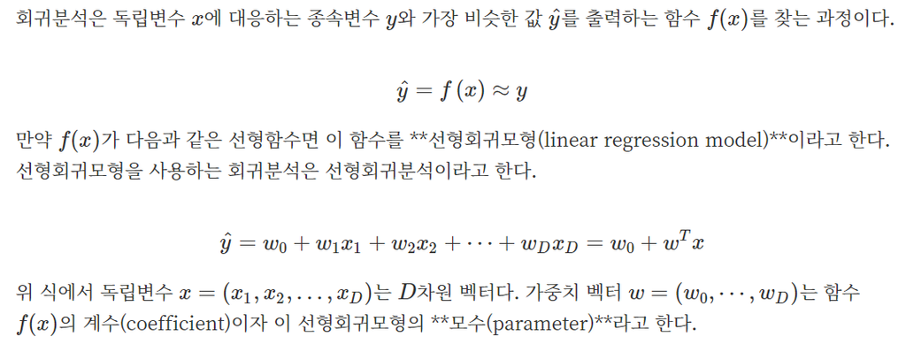

### [회귀분석의 작업]

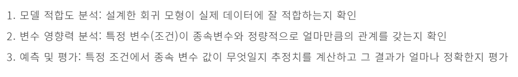

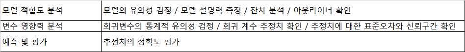

### [sklearn의 LinearRegression 클래스]

- 예측값과 실제 값의 RSS(Residual Sum of Squares)를 최소화해 OLS(Ordinary Least Squares) 추정 방식으로 구현한 클래스이며, fit() method로 X, y 배열을 입력 받으면 회귀 계수(Coefficients)인 W를 coef_ 속성에 저장한다.
- Ordinary Least Squares 기반의 회귀 계수 계산은 입력 feature의 독립성에 많은 영향을 받는다. feature 간의 상관관계가 매우 높은 경우 분산이 커져서 오류에 매우 민감해진다. 이러한 현상으 공신성(multi-collinearity) 문제라고 한다. 일반적으로 상관관계가 높은 feature가 많은 경우 독립적인 중요한 feature만 남기고 제거하거나 규제를 적용한다. 또한 매우 많은 feature가 다중 공선성 문제를 가지고 있다면 PCA를 통해 차원 축소를 수행하는 것도 고려해 볼 수 있다.
- 옵션값
  - class sklearn.linear_model.LinearRegression(fit_intercept=True, normalize=Flase, copy_X=True, n_jobs=1

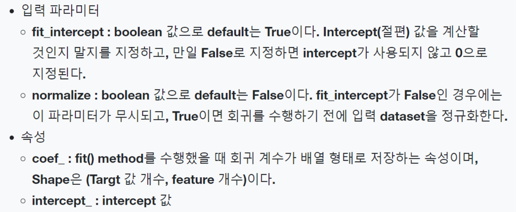

#### 참고: 정규분포 https://m.blog.naver.com/pmw9440/221805677577

### [분산 분석(ANOVA)]

- 분산 분석(ANOVA: Analysis of Variance)은 종속변수의 분산과 독립변수의 분산간의 관계를 사용하여 선형회귀분석의 성능을 평가하고자 하는 방법이다. 분산 분석은 서로 다른 두 개의 선형회귀분석의 성능 비교에 응용할 수 있으며 독립변수가 카테고리 변수인 경우 각 카테고리 값에 따른 영향을 정량적으로 분석하는데도 사용된다.
  - TSS: TSS는 종속변수값의 움직임의 범위를 나타낸다.
  - ESS(explained sum of squares): y예측값의 분산(모형의 예측값의 움직임의 범위)_잔차값
    - 잔차값에대한 부분은 이 자료 가장 하단에 있음
  - RSS(residual sum of squares): y값과 y예측값의차이(잔차 e)의 분산(오차의 크기)
- 모델 성능 평가요소 R-squared(R^2) 모형이 데이터에 잘 맞는 정도를 보여주는 지표중 하나이며 wx+b가 얼마나 선형적인가를 나타냄 범위는 0에서 1 사이의 값으로 0이면 모델의 설명력이 전혀 없는 상태이고, 1에 가까울수록 모델이 데이터를 잘 성명해 주는 상태라고 할 수 있다. 보통은 0.4 이상이면 괜찮은 모델이라 할 수 있다.

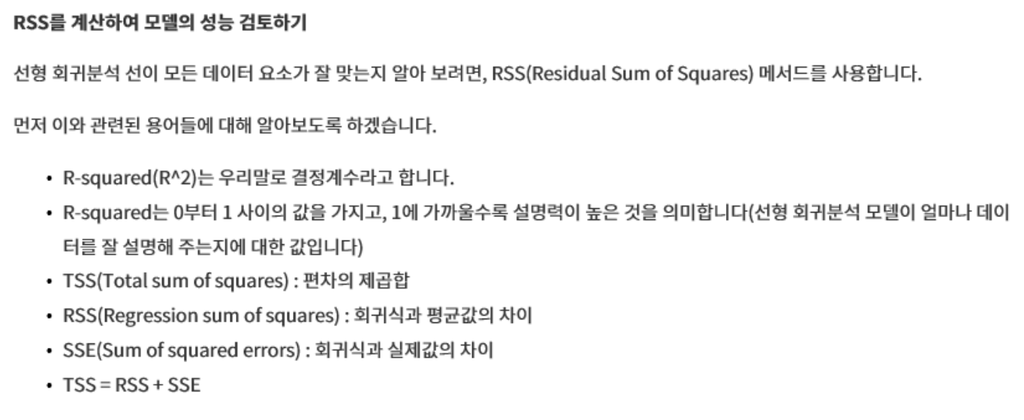

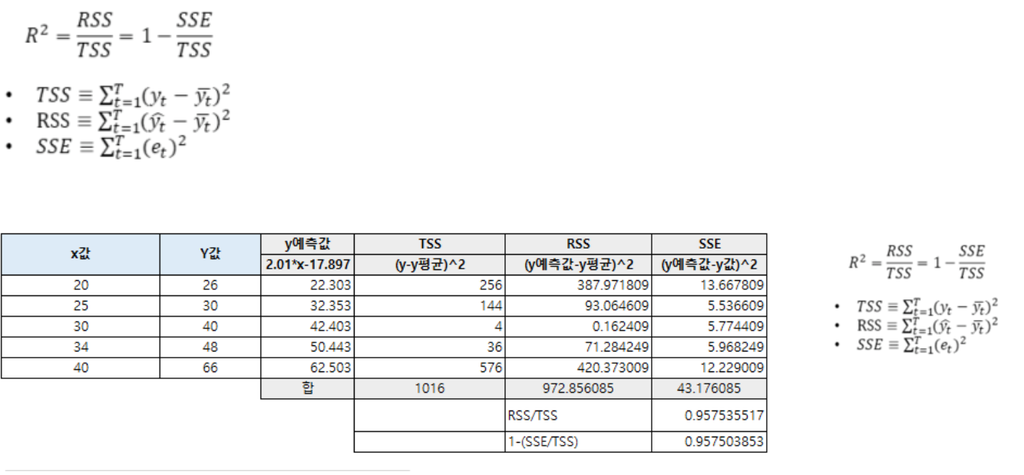

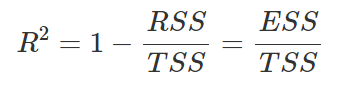

#### 참고로 읽어 보세요 : https://umbum.dev/865

```python
import numpy as np
import pandas as pd
from sklearn.linear_model import LinearRegression
from sklearn.metrics import r2_score


x=[20,25,30,34,40];x=np.array(x).reshape(-1,1)
y=[26,30,40,48,66]; y=np.array(y).reshape(-1,1)



model=LinearRegression()
model.fit(x,y)
y_preds = model.predict(x)

### --------- 위의 수식으로 R2값을 구해봅니다. --------
print('-- 직접 계산한 R-squared(R^2) 값---')
SSE=np.sum((y-model.predict(x))**2)
print('SSE:%.2f' % SSE)   # rss값은 sse값임.
TSS=np.sum((y-np.mean(y))**2)
print('TSS:%.2f' % TSS)
print('R2= 1-SSE/TSS: %.3f'% (1-SSE/TSS ))


### ------ 사이킷런에서 제공하는 R2 score값을 출력해봅니다.-----
print( '\n--- 사이킷런제공 R-squared(R^2)값 ----')
# print('회귀계수 %.4f '%model.coef_)
print('r2값 %.3f'%r2_score(y, y_preds))  # 아래의 score와 같은 값임.
print('socre값(결정계수 R값) %.3f' % model.score(x,y))


## 참고: R^2는 y값과 y예측값의 상관계수 제곱과 같아서 R^2라고 함.
```

```
-- 직접 계산한 R-squared(R^2) 값---
SSE:43.18
TSS:1016.00
R2= 1-SSE/TSS: 0.958

--- 사이킷런제공 R-squared(R^2)값 ----
r2값 0.958
socre값(결정계수 R값) 0.958
```

### [회귀 또는 분류 분석의 모형 적합도 판별]

- R2 값을 확인하고
- 회귀계수를 확인하여 모델에 영향을 주는 feature값들의 순서를 확인하고
- p-value값이 0.05보다 큰 값을 확인 (0.05보다 큰값은 제거하고 다시 모델링해보기도 함)

### [피어슨 상관계수와 p-value]

- 상관분석의 정의 (출처: https://ko.wikipedia.org/wiki/%EC%83%81%EA%B4%80_%EB%B6%84%EC%84%9D)
  - 상관 분석(相關 分析, Correlation analysis) 또는 '상관관계' 또는 '상관'은 확률론과 통계학에서 두 변수간에 어떤 선형적 또는 비선형적 관계를 갖고 있는지를 분석하는 방법이다. 두 변수는 서로 독립적인 관계이거나 상관된 관계일 수 있으며 이때 두 변수간의 관계의 강도를 상관관계(Correlation, Correlation coefficient)라 한다. 상관분석에서는 상관관계의 정도를 나타내는 단위로 모상관계수로 ρ를 사용하며 표본 상관 계수로 r 을 사용한다. 상관관계의 정도를 파악하는 상관 계수(相關係數, Correlation coefficient)는 두 변수간의 연관된 정도를 나타낼 뿐 인과관계를 설명하는 것은 아니다. 두 변수간에 원인과 결과의 인과관계가 있는지에 대한 것은 회귀분석을 통해 인과관계의 방향, 정도와 수학적 모델을 확인해 볼 수 있다.
- 피어슨 상관계수두 변수의 선형 상관 관계를 계량화한 수치입니다. 결과값은 -1 ~ 1 사이의 값이며,
- 양의 상관 관계가 있을수록 1에 가깝고, 음의 상관 관계가 있을수록 -1에 가까움 또한, 상관 관계가 없을수록 0에 가까움
- 참고: 피어슨, 스피어만등 상관계수의 이해 https://mindscale.kr/course/basic-stat-r/correaltion/

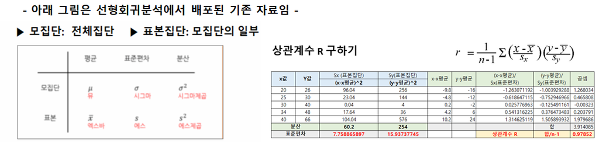

- 상관계수의 변수값의 특징
  - 두 변수는 연속형 변수이다.
  - 두 변수는 정규분포를 따른다. (간혹 한 변수만 정규분포를 따라도 된다고는 하지만, 이론적으로는 두 변수 모두 정규분포를 따라야합니다.)
  - 두 변수는 선형 관계를 가진다.
  - 이상치값이 있으면 극단적으로 값이 크거나 작은 경우가 포함되어 있어 결과가 왜곡될 수 있다.
- P-value(Probability Value)
  - p-value값은 정규성 검증을 위해 사용되는 p값은 모집단에서 상관계수가 0일때, 현재(여기서는 R^2값 0.958)와 같은 크기의 표본에서 관찰된 상관계수보다 더 극단적인 상관계수가 관찰될 확률
  - 보통 0.05(5%)와 같은 임계치를 정하고, p<0.05보다 작을경우 '통계적으로 유의미 하다'라고 함.
  - (과거부터 통용되는 값이며 상황에 따라 변경할수 있음.)
  - p-value값이 0.05보다 작으면 귀무가설의 기각 근거로 사용되어 feature값으로써 사용가능함을 뜻함.(=두 값이 서로 다른 분포에서 유래되었다, 동시에 100번 실험해서 거짓양성이 나올 확률이 5% 미만)

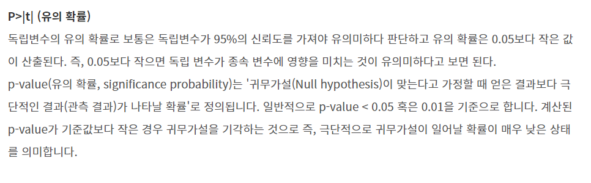

## [p-value값이 가장 작은 변수가 y값에 가장 설명능력이 좋음]

- OLS(Ordinary Least Squares) 패키지(https://www.statsmodels.org/stable/index.html)
- R2 값
- 회귀계수값 확인
- p-value값이 0.05보다 큰 값을 확인 (0.05보다 큰값은 제거하고 다시 모델링함)

OLS 개념 출처: https://ko.wikipedia.org/wiki/%EC%84%A0%ED%98%95_%ED%9A%8C%EA%B7%80#%EC%B5%9C%EC%86%8C%EC%A0%9C%EA%B3%B1%EB%B2%95

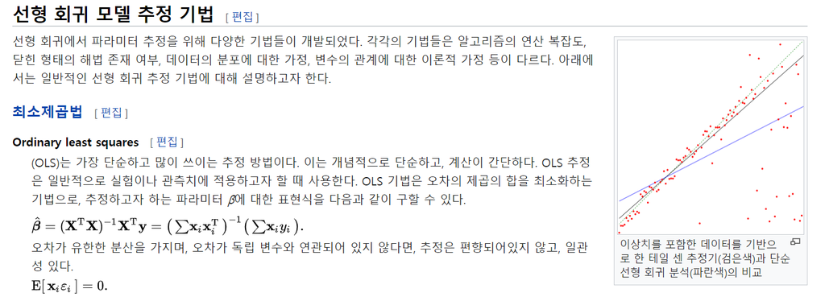

```python
#!pip install statsmodels
```

```python
#from statsmodels.formula.api import ols
# 참고: 로지스틱 회귀에서도 사용가능
import statsmodels.api as sm
```

### [OLS 모듈 결과표- 현재는 절편이 없는 자료임]

- 기본 ols 모듈(패키지)은 intercept(절편,b)값이 제공되지 않아 상수항을 추가하기 전까지는
- sklearn.linear_model 의 r^2 값과 다르게 계산됨

모형에서 절편을 제거한 경우 R제곱을 해석할 때 주의가 필요하다. 절편이 있는 경우와 없는 경우 계산 방식이 다르기 때문이다. 절편이 있는 경우에 R제곱은 종속변수의 분산에서 설명하는 비율을 나타내지만, 절편이 없는 경우는 종속변수의 제곱의 평균에서 설명하는 비율을 나타낸다.

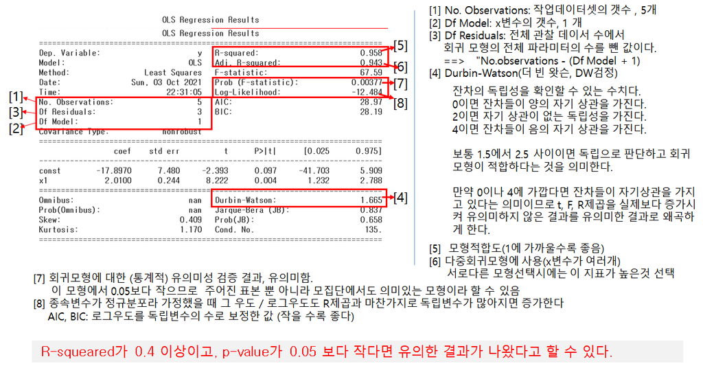

- 아래내용 출처: https://mindscale.kr/course/basic-stat-python/11/

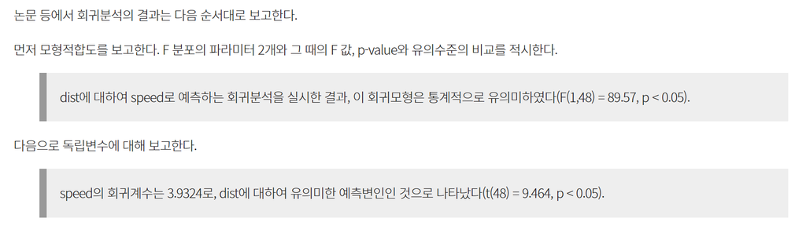

```python
x1=[20,25,30,34,40];x=np.array(x).reshape(-1,1)
y1=[26,30,40,48,66]; y=np.array(y).reshape(-1,1)

model_sm1 = sm.OLS(y1, x1)    #  y,x 를 y~x로 표현가능, y~x1+x2+x3도 가능
result1= model_sm1.fit()
print(result1.summary())
print('가중치 벡터값',result1.params)   # coef_값만 나옴, 여기서는 b값이 포함안됨

print('\n---예측값--------')
result1.predict([3]) # 3 에 대한 y_예측값
```

```
                                 OLS Regression Results
=======================================================================================
Dep. Variable:                      y   R-squared (uncentered):                   0.987
Model:                            OLS   Adj. R-squared (uncentered):              0.984
Method:                 Least Squares   F-statistic:                              309.3
Date:                Mon, 04 Oct 2021   Prob (F-statistic):                    6.14e-05
Time:                        02:35:27   Log-Likelihood:                         -15.153
No. Observations:                   5   AIC:                                      32.31
Df Residuals:                       4   BIC:                                      31.92
Df Model:                           1
Covariance Type:            nonrobust
==============================================================================
                 coef    std err          t      P>|t|      [0.025      0.975]
------------------------------------------------------------------------------
x1             1.4403      0.082     17.588      0.000       1.213       1.668
==============================================================================
Omnibus:                          nan   Durbin-Watson:                   0.881
Prob(Omnibus):                    nan   Jarque-Bera (JB):                1.014
Skew:                           1.098   Prob(JB):                        0.602
Kurtosis:                       2.792   Cond. No.                         1.00
==============================================================================

Notes:
[1] R² is computed without centering (uncentered) since the model does not contain a constant.
[2] Standard Errors assume that the covariance matrix of the errors is correctly specified.
가중치 벡터값 [1.44029054]

---예측값--------
```

```
array([4.32087161])
```

```python
# 분산 분석(ANOVA: Analysis of Variance)
# TSS:  종속변수값의 움직임의 범위를 나타낸다.
# ESS(explained sum of squares): y예측값의 분산(모형의 예측값의 움직임의 범위)
# RSS(residual sum of squares): y값과 y예측값의차이(잔차 e)의 분산(오차의 크기)

# OLS 모델에서의 R^2 값등 분산값 확인
# sklearn.linear_model 값과 다름, 아래의 상수항 추가하면 같아짐

print("TSS = ", result1.uncentered_tss)
print("ESS = ", result1.mse_model)
print("RSS = ", result1.ssr)
print("ESS + RSS = ", result1.mse_model + result1.ssr)
print("R squared = ", result1.rsquared)
```

[output not shown]

```
TSS =  9836
ESS =  9710.438795129247
RSS =  125.56120487075411
ESS + RSS =  9836.0
R squared =  0.9872345257349783
```

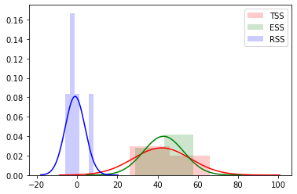

```python
import seaborn as sns
import matplotlib.pyplot as plt
from scipy import stats


sns.distplot(y1,
             kde=False, fit=stats.norm, hist_kws={"color": "r", "alpha": 0.2}, fit_kws={"color": "r"},
             label="TSS")
sns.distplot(result1.fittedvalues,
             kde=False, hist_kws={"color": "g", "alpha": 0.2}, fit=stats.norm, fit_kws={"color": "g"},
             label="ESS")
sns.distplot(result1.resid,
             kde=False, hist_kws={"color": "b", "alpha": 0.2}, fit=stats.norm, fit_kws={"color": "b"},
             label="RSS")
plt.legend()
plt.show()
```